# Project 1

James Eapen

2021 Oct 4

## Assignment tracker

[source](https://github.com/jamespeapen/expdesign/blob/gh-pages/project1.rmd)

### Setup

```r
library("tidyverse")
library("lubridate")
library("ggplot2")
library("RColorBrewer")
```

### Data loading

```r
sheets_url <- "https://docs.google.com/spreadsheets/d/1bJw_ad0PLQmLe4RvmRzsVnrOF-9Z9Xth9GTSdwO8B4M"
googlesheets4::gs4_deauth()
raw_data <- googlesheets4::read_sheet(sheets_url)

# rename columns
colnames(raw_data)  <- c("timestamp",
                      "ID",
                      "assignment",
                      "start_time",
                      "end_time",
                      "comments")
```

### Cleanup

#### IDs

Find out how many IDs there are with counts.

```r
table(raw_data$ID) %>% knitr::kable()
```

| Var1 | Freq |
| --- | --- |
| b5548ea | 11 |
| Blobfish | 7 |
| Bubbles | 6 |
| Capybara | 12 |
| cruise control | 5 |
| FooBarBazQux | 1 |
| Panicking Pangolin | 7 |
| Porg | 7 |
| Puppy | 5 |
| Rafiki | 10 |
| scientist101 | 9 |
| T-rex | 9 |
| T-Rex | 1 |
| Tall drink of water | 8 |

FooBarBazQux is Tim so I’ll remove that row of data.

```r
raw_data %>% filter(ID != "FooBarBazQux") -> raw_data
```

T-rex has two IDs so replace “T-Rex” with “T-rex” to be consistent.

```r
# piped object can be accessed with .
raw_data$ID %>% replace(. == "T-Rex", "T-rex") -> raw_data$ID
table(raw_data$ID) %>% knitr::kable()
```

| Var1 | Freq |
| --- | --- |
| b5548ea | 11 |
| Blobfish | 7 |
| Bubbles | 6 |
| Capybara | 12 |
| cruise control | 5 |
| Panicking Pangolin | 7 |
| Porg | 7 |
| Puppy | 5 |
| Rafiki | 10 |
| scientist101 | 9 |
| T-rex | 10 |
| Tall drink of water | 8 |

#### Assignments

```r
raw_data$assignment %>% table() %>% sort() %>% knitr::kable()
```

| . | Freq |
| --- | --- |
| ch 23,24,29 | 1 |
| Ch 3 Lab | 1 |
| Ch 3.6 lab | 1 |
| Chapter 23,24,29 | 1 |
| Chapter 6 ISLRv2 | 1 |
| Chapters 23, 24, 29 | 1 |
| Fiddling with ISLRV2 Ch2 lab: trying to make it make sense | 1 |
| Git with RStudio | 1 |
| ISLR ch 6 | 1 |
| ISLR ch6 | 1 |
| islrv2 3.6 lab | 1 |
| Lab 3.6, tidymodels version | 1 |
| Lab: ISLRv2 Chapter 2 assignment | 1 |
| Project Management with R Studio | 1 |
| Project Management With RStudio | 1 |
| R Studio Carpentry - Project Management and Using R studio | 1 |
| Reading: Experimental Design for Biologists (ch 23,24, 29) | 1 |
| Reading: ISLRv2 Chapter 6 | 1 |
| Skim Chapter ISLRv2 Ch. 6 | 1 |
| Lab: ISLRv2 Chapter 3 lab assignment | 2 |
| Project Management | 2 |
| Reading: Linear Model Selection and Regularization (chapter 6) | 2 |
| Using Git from Rstudio | 2 |
| Using Git from RStudio | 2 |
| Reading: Intro to Statistical Learning 2nd edition (chapter 3) | 10 |
| Lab: Rstudio Carpentry (introduction) | 11 |
| Reading: Intro to Statistical Learning 2nd edition (chapters 1 and 2) | 11 |
| Lab: ISLRv2 Chapter 2 lab assignment | 12 |
| Lab: Rstudio Analyzing Patient Data (practicum) | 12 |
| Reading: Experimental Design for Biologists (chapters 16, 17, 18) | 12 |

`assignment` has 30 unique elements and is much messier so I’ll start with the assignments with somewhat consistent words in their names. Since some assignments have ‘Git’ and ‘Project Management’ occurring consistently, I’ll use regular expressions to find all the rows with ‘Git’ or ‘Project Management’ and replace them with “Using Git from RStudio” and “Project Management with RStudio”.

`.*` in regex means match anything, so it’ll match any string as long as it has ‘git’ or ‘project management’. This will be case-insensitive matching.

```r
#'?' matches whether there is a space before git or not
raw_data$assignment %>%
    sub(".* ?git .*", "Using Git from RStudio", ., ignore.case = TRUE) ->
        raw_data$assignment

raw_data$assignment %>%
    sub(".*project management.*", "Project Management with RStudio", .,
        ignore.case = TRUE) -> raw_data$assignment

raw_data$assignment %>% table() %>% sort() %>% knitr::kable()
```

| . | Freq |
| --- | --- |
| ch 23,24,29 | 1 |
| Ch 3 Lab | 1 |
| Ch 3.6 lab | 1 |
| Chapter 23,24,29 | 1 |
| Chapter 6 ISLRv2 | 1 |
| Chapters 23, 24, 29 | 1 |
| Fiddling with ISLRV2 Ch2 lab: trying to make it make sense | 1 |
| ISLR ch 6 | 1 |
| ISLR ch6 | 1 |
| islrv2 3.6 lab | 1 |
| Lab 3.6, tidymodels version | 1 |
| Lab: ISLRv2 Chapter 2 assignment | 1 |
| Reading: Experimental Design for Biologists (ch 23,24, 29) | 1 |
| Reading: ISLRv2 Chapter 6 | 1 |
| Skim Chapter ISLRv2 Ch. 6 | 1 |
| Lab: ISLRv2 Chapter 3 lab assignment | 2 |
| Reading: Linear Model Selection and Regularization (chapter 6) | 2 |
| Project Management with RStudio | 5 |
| Using Git from RStudio | 5 |
| Reading: Intro to Statistical Learning 2nd edition (chapter 3) | 10 |
| Lab: Rstudio Carpentry (introduction) | 11 |
| Reading: Intro to Statistical Learning 2nd edition (chapters 1 and 2) | 11 |
| Lab: ISLRv2 Chapter 2 lab assignment | 12 |
| Lab: Rstudio Analyzing Patient Data (practicum) | 12 |
| Reading: Experimental Design for Biologists (chapters 16, 17, 18) | 12 |

There are now 25 unique assignment names.

And again by matching for any occurrences of ‘23’, ‘24’, and ‘29’ in the same string. I’ll be adding the ‘Reading’ and ‘Lab’ prefixes to better organize the data.

```r
raw_data$assignment %>%
    sub(".*23.*24.*29.*", "Reading: Experimental Design for Biologists Ch. 23, 24, 29", .,
        ignore.case = TRUE) -> raw_data$assignment

raw_data$assignment %>% table() %>% sort() %>% knitr::kable()
```

| . | Freq |
| --- | --- |
| Ch 3 Lab | 1 |
| Ch 3.6 lab | 1 |
| Chapter 6 ISLRv2 | 1 |
| Fiddling with ISLRV2 Ch2 lab: trying to make it make sense | 1 |
| ISLR ch 6 | 1 |
| ISLR ch6 | 1 |
| islrv2 3.6 lab | 1 |
| Lab 3.6, tidymodels version | 1 |
| Lab: ISLRv2 Chapter 2 assignment | 1 |
| Reading: ISLRv2 Chapter 6 | 1 |
| Skim Chapter ISLRv2 Ch. 6 | 1 |
| Lab: ISLRv2 Chapter 3 lab assignment | 2 |
| Reading: Linear Model Selection and Regularization (chapter 6) | 2 |
| Reading: Experimental Design for Biologists Ch. 23, 24, 29 | 4 |
| Project Management with RStudio | 5 |
| Using Git from RStudio | 5 |
| Reading: Intro to Statistical Learning 2nd edition (chapter 3) | 10 |
| Lab: Rstudio Carpentry (introduction) | 11 |
| Reading: Intro to Statistical Learning 2nd edition (chapters 1 and 2) | 11 |
| Lab: ISLRv2 Chapter 2 lab assignment | 12 |
| Lab: Rstudio Analyzing Patient Data (practicum) | 12 |
| Reading: Experimental Design for Biologists (chapters 16, 17, 18) | 12 |

There are now 22 unique assignment names.

Getting Ch. 2 and 3 labs and chapter 6 reading is a little more complex. Chaper 3 matches needs two patterns separated by `|` to match both:

```r
raw_data$assignment %>%
    sub(".*Ch(apter)? ?2.*(assignment|lab).*", "Lab: ISLRv2 Chapter 2", .,
        ignore.case = TRUE) -> raw_data$assignment

raw_data$assignment %>% table() %>% sort() %>% knitr::kable()
```

| . | Freq |
| --- | --- |
| Ch 3 Lab | 1 |
| Ch 3.6 lab | 1 |
| Chapter 6 ISLRv2 | 1 |
| ISLR ch 6 | 1 |
| ISLR ch6 | 1 |
| islrv2 3.6 lab | 1 |
| Lab 3.6, tidymodels version | 1 |
| Reading: ISLRv2 Chapter 6 | 1 |
| Skim Chapter ISLRv2 Ch. 6 | 1 |
| Lab: ISLRv2 Chapter 3 lab assignment | 2 |
| Reading: Linear Model Selection and Regularization (chapter 6) | 2 |
| Reading: Experimental Design for Biologists Ch. 23, 24, 29 | 4 |
| Project Management with RStudio | 5 |
| Using Git from RStudio | 5 |
| Reading: Intro to Statistical Learning 2nd edition (chapter 3) | 10 |
| Lab: Rstudio Carpentry (introduction) | 11 |
| Reading: Intro to Statistical Learning 2nd edition (chapters 1 and 2) | 11 |
| Lab: Rstudio Analyzing Patient Data (practicum) | 12 |
| Reading: Experimental Design for Biologists (chapters 16, 17, 18) | 12 |
| Lab: ISLRv2 Chapter 2 | 14 |

```r
raw_data$assignment %>%
    sub(".*Ch.*3.*lab.*|.*3.6.*", "Lab: ISLRv2 Chapter 3", .,
        ignore.case = TRUE) -> raw_data$assignment

raw_data$assignment %>% table() %>% sort() %>% knitr::kable()
```

| . | Freq |
| --- | --- |
| Chapter 6 ISLRv2 | 1 |
| ISLR ch 6 | 1 |
| ISLR ch6 | 1 |
| Reading: ISLRv2 Chapter 6 | 1 |
| Skim Chapter ISLRv2 Ch. 6 | 1 |
| Reading: Linear Model Selection and Regularization (chapter 6) | 2 |
| Reading: Experimental Design for Biologists Ch. 23, 24, 29 | 4 |
| Project Management with RStudio | 5 |
| Using Git from RStudio | 5 |
| Lab: ISLRv2 Chapter 3 | 6 |
| Reading: Intro to Statistical Learning 2nd edition (chapter 3) | 10 |
| Lab: Rstudio Carpentry (introduction) | 11 |
| Reading: Intro to Statistical Learning 2nd edition (chapters 1 and 2) | 11 |
| Lab: Rstudio Analyzing Patient Data (practicum) | 12 |
| Reading: Experimental Design for Biologists (chapters 16, 17, 18) | 12 |
| Lab: ISLRv2 Chapter 2 | 14 |

```r
raw_data$assignment %>%
    sub(".*Ch(apter)?.? ?6.*", "Reading: ISLRv2 Chapter 6", .,
        ignore.case = TRUE) -> raw_data$assignment

raw_data$assignment %>% table() %>% sort() %>% knitr::kable()
```

| . | Freq |
| --- | --- |
| Reading: Experimental Design for Biologists Ch. 23, 24, 29 | 4 |
| Project Management with RStudio | 5 |
| Using Git from RStudio | 5 |
| Lab: ISLRv2 Chapter 3 | 6 |
| Reading: ISLRv2 Chapter 6 | 7 |
| Reading: Intro to Statistical Learning 2nd edition (chapter 3) | 10 |
| Lab: Rstudio Carpentry (introduction) | 11 |
| Reading: Intro to Statistical Learning 2nd edition (chapters 1 and 2) | 11 |
| Lab: Rstudio Analyzing Patient Data (practicum) | 12 |
| Reading: Experimental Design for Biologists (chapters 16, 17, 18) | 12 |
| Lab: ISLRv2 Chapter 2 | 14 |

Now with those collected there are 11 assignments.

### Data exploration

#### Datatable

```r
# get durations
raw_data %>% mutate(duration = as.numeric(end_time - start_time)) -> assignments
DT::datatable(assignments)
```

|  | timestamp | ID | assignment | start_time | end_time | comments | duration |
| --- | --- | --- | --- | --- | --- | --- | --- |
| 1 | 2021-09-01T18:39:09Z | T-rex | Reading: Intro to Statistical Learning 2nd edition (chapters 1 and 2) | 1899-12-30T17:28:00Z | 1899-12-30T06:37:00Z | I will likely need to go back and re-read some of these sections as they can be a little hard to digest at times. | -651.000000007947 |
| 2 | 2021-09-04T13:57:26Z | b5548ea | Reading: Intro to Statistical Learning 2nd edition (chapters 1 and 2) | 1899-12-30T12:00:00Z | 1899-12-30T14:50:00Z |  | 170 |
| 3 | 2021-09-04T13:58:26Z | b5548ea | Lab: Rstudio Carpentry (introduction) | 1899-12-30T15:00:00Z | 1899-12-30T15:03:00Z |  | 3 |
| 4 | 2021-09-04T13:59:05Z | b5548ea | Lab: Rstudio Analyzing Patient Data (practicum) | 1899-12-30T15:04:00Z | 1899-12-30T15:40:01Z |  | 36.0000000079473 |
| 5 | 2021-09-04T14:15:46Z | b5548ea | Lab: ISLRv2 Chapter 2 | 1899-12-30T16:00:00Z | 1899-12-30T16:15:00Z |  | 15 |
| 6 | 2021-09-07T09:31:27Z | b5548ea | Reading: Experimental Design for Biologists (chapters 16, 17, 18) | 1899-12-30T09:03:00Z | 1899-12-30T09:30:00Z |  | 27 |
| 7 | 2021-09-07T15:07:17Z | Blobfish | Reading: Experimental Design for Biologists (chapters 16, 17, 18) | 1899-12-30T10:30:00Z | 1899-12-30T11:30:00Z | Book is easy to read with good experimental examples and diagrams | 60 |
| 8 | 2021-09-07T15:48:45Z | T-rex | Reading: Experimental Design for Biologists (chapters 16, 17, 18) | 1899-12-30T03:25:00Z | 1899-12-30T03:48:00Z |  | 23 |
| 9 | 2021-09-08T20:56:58Z | Rafiki | Reading: Experimental Design for Biologists (chapters 16, 17, 18) | 1899-12-30T11:00:00Z | 1899-12-30T11:57:00Z | I enjoyed the reading. Eager to put these thought process into experimental design in the near future | 57 |
| 10 | 2021-09-08T20:59:10Z | Rafiki | Reading: Intro to Statistical Learning 2nd edition (chapters 1 and 2) | 1899-12-30T18:00:00Z | 1899-12-30T21:12:00Z | This was a much tougher read - mostly understanding the Math behind it all in pages 10-12 and then more math stuff after that. It will take time to understand this/be confident of my understanding but… | 192 |

[output cut: 87 more lines]

#### Number of assignments done per person

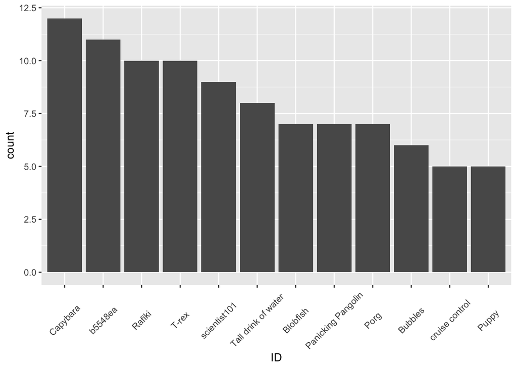

```r
assignments %>%
    ggplot(aes(x = forcats::fct_infreq(ID))) + # forcats::fct_infreq sorts the IDs by count
    geom_bar(stat = "count") +
    xlab("ID") +
    theme(axis.text.x = element_text(angle = 45, vjust = 0.5))
```

#### Time taken per person

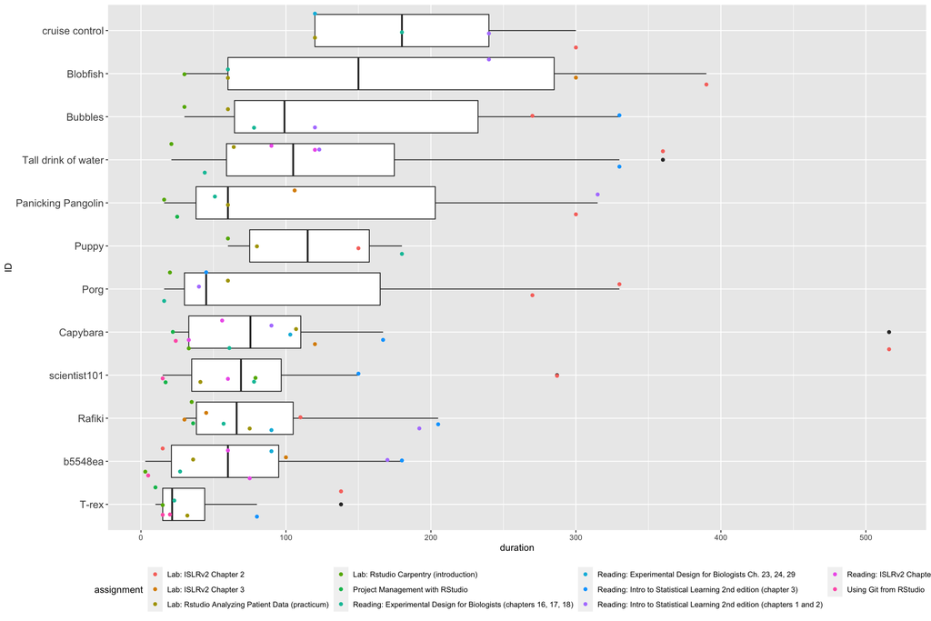

```r
# filter for durations > 0 since the duration calc got negatives
nonz_durations <- assignments %>% subset(duration > 0)
nonz_durations %>%
    ggplot(aes(x = reorder(ID, duration), y = duration)) +
    geom_boxplot() +
    geom_jitter(aes(color = assignment)) +
    xlab("ID") +
    theme(legend.position = "bottom",
          axis.text.y = element_text(size = 12)) +
    coord_flip()
```

The assignment names are quite long so I’ll shorten the ISLRv2 full name to the abbreviation.

```r
nonz_durations$assignment %>%
    sub("Intro .* edition", "ISLRv2", .,
        ignore.case = TRUE) -> nonz_durations$assignment
nonz_durations$assignment %>% table() %>% knitr::kable()
```

| . | Freq |
| --- | --- |
| Lab: ISLRv2 Chapter 2 | 13 |
| Lab: ISLRv2 Chapter 3 | 6 |
| Lab: Rstudio Analyzing Patient Data (practicum) | 12 |
| Lab: Rstudio Carpentry (introduction) | 11 |
| Project Management with RStudio | 5 |
| Reading: Experimental Design for Biologists (chapters 16, 17, 18) | 12 |
| Reading: Experimental Design for Biologists Ch. 23, 24, 29 | 4 |
| Reading: ISLRv2 (chapter 3) | 8 |
| Reading: ISLRv2 (chapters 1 and 2) | 9 |
| Reading: ISLRv2 Chapter 6 | 7 |
| Using Git from RStudio | 5 |

#### Time taken per assignment

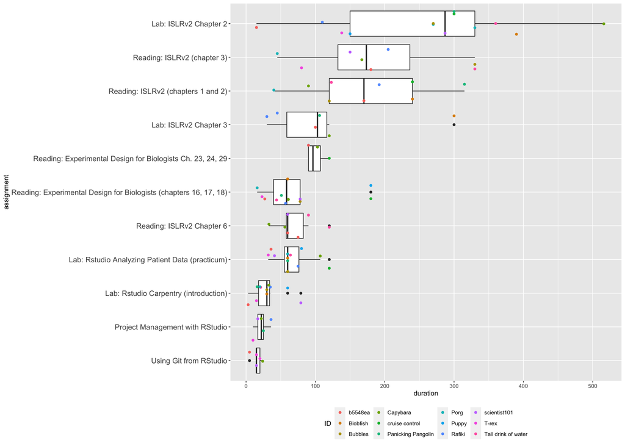

```r
nonz_durations %>%
    ggplot(aes(x = reorder(assignment, duration), y = duration)) +
    geom_boxplot() +
    geom_jitter(aes(color = ID)) +
    xlab("assignment") +
    theme(legend.position = "bottom",
          axis.text.y = element_text(size = 12)) +
    coord_flip()
```

To see how the type of assignment affects duration, I’ll add `assignment_type` and `assignment_source` columns.

```r
nonz_durations %>%
    mutate(assignment_type =
           case_when(
                     startsWith(assignment, "Reading") ~ "Reading",
                     startsWith(assignment, "Lab") ~ "Lab",
                     grepl("Project Management|Git", assignment) ~ "Reading")) %>%
    mutate(assignment_source =
           case_when(
                     grepl("ISLRv2", assignment) ~ "ISLRv2",
                     grepl("Experimental Design for Biologists", assignment) ~ "EDB",
                     grepl("RStudio", ignore.case = TRUE, assignment) ~ "Software Carpentry")) -> nonz_durations


nonz_durations %>% head() %>% knitr::kable()
```

| timestamp | ID | assignment | start_time | end_time | comments | duration | assignment_type | assignment_source |
| --- | --- | --- | --- | --- | --- | --- | --- | --- |
| 2021-09-04 13:57:26 | b5548ea | Reading: ISLRv2 (chapters 1 and 2) | 1899-12-30 12:00:00 | 1899-12-30 14:50:00 | NA | 170 | Reading | ISLRv2 |
| 2021-09-04 13:58:26 | b5548ea | Lab: Rstudio Carpentry (introduction) | 1899-12-30 15:00:00 | 1899-12-30 15:03:00 | NA | 3 | Lab | Software Carpentry |
| 2021-09-04 13:59:05 | b5548ea | Lab: Rstudio Analyzing Patient Data (practicum) | 1899-12-30 15:04:00 | 1899-12-30 15:40:01 | NA | 36 | Lab | Software Carpentry |
| 2021-09-04 14:15:46 | b5548ea | Lab: ISLRv2 Chapter 2 | 1899-12-30 16:00:00 | 1899-12-30 16:15:00 | NA | 15 | Lab | ISLRv2 |
| 2021-09-07 09:31:27 | b5548ea | Reading: Experimental Design for Biologists (chapters 16, 17, 18) | 1899-12-30 09:03:00 | 1899-12-30 09:30:00 | NA | 27 | Reading | EDB |
| 2021-09-07 15:07:17 | Blobfish | Reading: Experimental Design for Biologists (chapters 16, 17, 18) | 1899-12-30 10:30:00 | 1899-12-30 11:30:00 | Book is easy to read with good experimental examples and diagrams | 60 | Reading | EDB |

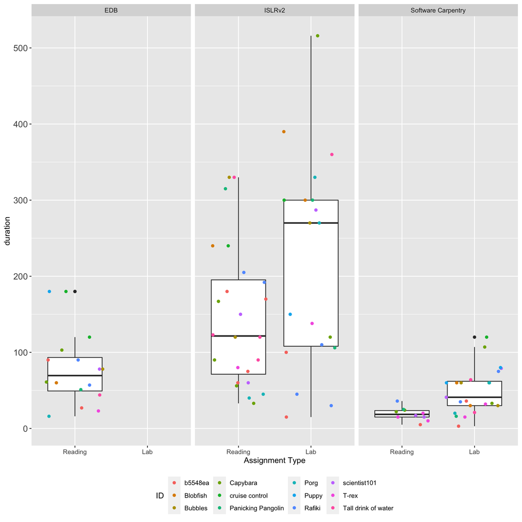

```r
nonz_durations %>%
    ggplot(aes(x = reorder(assignment_type, duration), y = duration)) +
    geom_boxplot() +
    geom_jitter(aes(color = ID)) +
    xlab("Assignment Type") +
    facet_grid(cols = vars(assignment_source)) +
    theme(legend.position = "bottom",
          axis.text.y = element_text(size = 12))
```